# Consequences and causal models

Class

Author

Joshua Loftus

## In class

1. A discussion of the arguments you brought.
2. Problem 1, by hand.
3. Problem 2, by hand, then a discussion.
4. One simulation in R, then a discussion.
5. One more discussion.

Discussions are in groups of three or four, then with the room. Each problem, and the simulation, is gone through as soon as the room has tried it. Everything under “Optional, can be done at home” is practice for afterward.

## Discussion 1: the arguments you brought

Put your arguments side by side and choose one.

1. What is the action, and which outcome does the argument count?
2. Draw the causal graph the argument needs, with an arrow for each cause-and-effect claim you listed. Mark the action.
3. Try to draw a second graph that fits the same evidence and under which the action does nothing. If the evidence makes every such graph hard to believe, say what in the evidence does that.
4. How could the analysis go wrong if the first graph is wrong? What would the consequences of the wrong conclusion be, and for whom?

Each group’s graphs, or what rules a rival out, go on the screen.

**NoteRival graphs**

Most arguments have a rival graph of one of two kinds: a common cause of the action and the outcome, or an arrow that points the other way. A rival graph does not show that your argument is wrong. It shows what evidence would tell the two graphs apart, which is usually a comparison in which the action was not chosen by the people, or the places, that also determine the outcome. If the argument rests on a randomized trial, no common cause of the assignment and the outcome can explain its result, because a coin decided who was assigned the action. What is left to question includes chance, whether what the coin assigned is the action the argument is about (some people do not take what they are assigned), and whether the people in the trial are like the people the policy is for.

## Problems

Before you start, from memory: what does the adjustment formula average, and with what weights?

**NoteSolution**

It averages the outcome among people with $X = x$ within each value of $Z$, with weights $P(Z = z)$: how common each value of $Z$ is in the whole population, not among the people with $X = x$.

### 1. Conditioning and intervening

A program in the style of the reading’s. $U_1, \dots, U_5$ are independent, with $U_1 \sim B(0.5)$, $U_2 \sim B(0.6)$, $U_3 \sim B(0.2)$, $U_4 \sim B(0.4)$ and $U_5 \sim B(0.1)$, where $B(0.6)$ is 1 with probability 0.6 and 0 otherwise.

1. $X := U_1$ (exercise)
2. $W :=$ if $X = 1$ then $U_3$ else $U_2$ (overweight)
3. $H :=$ if $X = 1$ then $U_5$ else $U_4$ (heart disease)
1. Draw the graph.
2. Compute $P(W = 1)$ and $P(X = 0 \mid W = 1)$.
3. Compute $P(H = 1)$, $P(H = 1 \mid W = 1)$ and $P(H = 1 \mid W = 0)$.
4. A program changes everyone’s weight to normal: $W := 0$. Compute $P(H = 1 \mid do(W := 0))$. What does the program do to heart disease?
5. Compute the average treatment effect of exercise on heart disease, and compare it with $P(H = 1 \mid X = 1) - P(H = 1 \mid X = 0)$. Are they equal? Why?

**TipHint 1**

For (b), use Bayes’ rule: $P(X = 0 \mid W = 1) = P(W = 1 \mid X = 0)\,P(X = 0)/P(W = 1)$.

**TipHint 2**

For (c), condition on $X$ first. Given $X$, $W$ and $H$ come from different coins, so they are independent.

**TipHint 3**

For (d), replace line 2 by $W := 0$ and keep the other two lines. Which variables does $H$ depend on now?

**NoteSolution**

1. $W \leftarrow X \to H$, a fork.
2. $P(W = 1) = 0.5 \times 0.2 + 0.5 \times 0.6 = 0.4$, and $P(X = 0 \mid W = 1) = 0.5 \times 0.6 / 0.4 = 0.75$.
3. $P(H = 1) = 0.5 \times 0.1 + 0.5 \times 0.4 = 0.25$. Given $X$, $H$ does not depend on $W$, so $P(H = 1 \mid W = 1) = 0.75 \times 0.4 + 0.25 \times 0.1 = 0.325$. For $W = 0$: $P(W = 0) = 0.6$ and $P(X = 0 \mid W = 0) = 0.5 \times 0.4/0.6 = 1/3$, so $P(H = 1 \mid W = 0) = \tfrac13 \times 0.4 + \tfrac23 \times 0.1 = 0.2$. Overweight people have heart disease at 0.325, the others at 0.2.
4. The line for $H$ is unchanged and $X$ keeps its distribution, so $P(H = 1 \mid do(W := 0)) = P(H = 1) = 0.25$, and the same for $do(W := 1)$. The weight program does nothing to heart disease, although overweight people had 12.5 points more of it.
5. $E[H \mid do(X := 1)] - E[H \mid do(X := 0)] = 0.1 - 0.4 = -0.3$, and $P(H = 1 \mid X = 1) - P(H = 1 \mid X = 0) = 0.1 - 0.4 = -0.3$. They are equal because no arrow points into $X$: it is set by a coin, as in a randomized trial, so there is no backdoor path from $X$ to $H$. Overweight people exercise less often (25% of them, against 50% of everyone), and that is where their extra heart disease comes from.

### 2. Adjusting for a confounder

A school offers a revision app before a test. Students who passed the previous year’s test ($Z = 1$) are more likely to use it ($X = 1$). The outcome is passing this year ($Y = 1$).

|  | used the app ($X = 1$) | did not ($X = 0$) |
| --- | --- | --- |
| passed last year ($Z = 1$), 500 students | 400, of whom 320 passed (80%) | 100, of whom 70 passed (70%) |
| did not ($Z = 0$), 500 students | 100, of whom 50 passed (50%) | 400, of whom 120 passed (30%) |

1. Compute the pass rates of users and non-users, and the difference.
2. Draw the graph you would assume, and compute the average treatment effect of the app with the adjustment formula.
3. Compute the difference within each row. How does the average treatment effect combine the two?
4. A second school has the same pass rates within each cell of the table, but only 20% of its students passed last year. What is the average treatment effect of the app there?
5. A head teacher asks whether to buy the app for every student. Which of your numbers would you report, and what would you say about it?

**TipHint 1**

For (a), count the users who passed in both rows, and divide by all users.

**TipHint 2**

For (b), the adjustment formula weights each row by its share of all students, not by its share of users.

**NoteSolution**

1. Users: $(320 + 50)/500 = 0.74$. Non-users: $(70 + 120)/500 = 0.38$. The difference is $0.36$.
2. $Z \to X$, $Z \to Y$, $X \to Y$. $E[Y \mid do(X := 1)] = 0.8 \times 0.5 + 0.5 \times 0.5 = 0.65$ and $E[Y \mid do(X := 0)] = 0.7 \times 0.5 + 0.3 \times 0.5 = 0.50$, so the average treatment effect is $0.15$.
3. $0.80 - 0.70 = 0.10$ among students who passed last year, and $0.50 - 0.30 = 0.20$ among those who did not. The average treatment effect is their average weighted by $P(Z = z)$: $0.10 \times 0.5 + 0.20 \times 0.5 = 0.15$.
4. $0.10 \times 0.2 + 0.20 \times 0.8 = 0.18$.
5. The average treatment effect, 0.15, compares everyone using the app with nobody using it, in this school’s mix of students. The head teacher’s decision is different in two ways. Half the students already use the app, so the comparison is with today’s pass rate, $560/1000 = 0.56$. If everyone used it the rate would be 0.65, an increase of 0.09. And buying the app gives access, not use, so the increase would be smaller if some students did not use it. The effect among today’s non-users is $(100 \times 0.10 + 400 \times 0.20)/500 = 0.18$, the same as in (d), because the non-users have the second school’s mix: 20% of them passed last year. All of it rests on the graph. If something unmeasured, such as motivation, pushed students both to use the app and to pass, adjusting for $Z$ would not give the effect.

## Discussion 2: correlation and causation

“Correlation (more generally, association) is not causation.” This is true and important, but can it be misused?

## Simulation: intervening in a program

The job center from the lecture, as a program. As in the lecture, everyone referred attends and nobody else does. Each line generates one variable from the ones above it.

```r
n <- 10000
Z <- rbinom(n, 1, 0.5)                        # worked last year
X <- rbinom(n, 1, ifelse(Z == 1, 0.8, 0.2))   # attended the course
Y <- rbinom(n, 1, 0.3 + 0.1 * X + 0.3 * Z)    # in work six months later
mean(Y[X == 1]) - mean(Y[X == 0])             # attenders against the others
```

1. Run it. Compare the difference with the lecture’s table.
2. Compute the adjusted difference: the difference between attenders and non-attenders within $Z = 1$ and within $Z = 0$, averaged with weights `mean(Z == 1)` and `mean(Z == 0)`.
3. Intervene. Replace the line for `X` by `X <- rep(1, n)`, run the line for `Y` again, and record `mean(Y)`. Do the same with `X <- rep(0, n)`. Compare the difference with your answer to 2.
4. The center changes its referrals to 0.95 for $Z = 1$ and 0.05 for $Z = 0$. Before you run anything, write down what you expect for the differences in 1 and in 3. Then run it.

**TipHint 1**

For step 3, replace the line for `X` and leave the line for `Z` alone. Then run the line for `Y` again, so that it uses the new `X`.

**NoteSolution**

```r
n <- 10000
Z <- rbinom(n, 1, 0.5)
X <- rbinom(n, 1, ifelse(Z == 1, 0.8, 0.2))
Y <- rbinom(n, 1, 0.3 + 0.1 * X + 0.3 * Z)
observed <- mean(Y[X == 1]) - mean(Y[X == 0])
d1 <- mean(Y[X == 1 & Z == 1]) - mean(Y[X == 0 & Z == 1])   # within Z = 1
d0 <- mean(Y[X == 1 & Z == 0]) - mean(Y[X == 0 & Z == 0])   # within Z = 0
adjusted <- d1 * mean(Z == 1) + d0 * mean(Z == 0)
Y1 <- rbinom(n, 1, 0.3 + 0.1 * 1 + 0.3 * Z)    # everyone attends
Y0 <- rbinom(n, 1, 0.3 + 0.1 * 0 + 0.3 * Z)    # nobody attends
c(observed = observed, adjusted = adjusted, intervened = mean(Y1) - mean(Y0))
```

```
  observed   adjusted intervened
 0.2813623  0.1046528  0.1067000
```

```r
X95 <- rbinom(n, 1, ifelse(Z == 1, 0.95, 0.05))
Y95 <- rbinom(n, 1, 0.3 + 0.1 * X95 + 0.3 * Z)
mean(Y95[X95 == 1]) - mean(Y95[X95 == 0])      # observed, new referrals
```

```
[1] 0.3798091
```

1. About $0.28$, the table’s $0.64 - 0.36$.
2. About $0.10$.
3. About $0.10$: intervening deletes the arrow $Z \to X$, and the adjusted difference estimates the same quantity.
4. The observed difference grows to about $(0.95 \times 0.7 + 0.05 \times 0.4) - (0.05 \times 0.6 + 0.95 \times 0.3) = 0.685 - 0.315 = 0.37$. The effect of the course stays at $0.10$: the referral policy changes who attends, not what the course does. Each run differs from these numbers by a few hundredths.

## Discussion 3: causality and reproducibility

Can causality be useful in the context of reproducibility?

## Discussion 4: writing the model down

Does consequentialism become more or less defensible once you have to write the causal model down? Answer it first for the argument your group drew at the start.

## If there is time

- Can causality be useful for designing and communicating studies?
- A company tests two versions of its app on its users, without telling them, to see which version keeps them using the app longer. Which of the Belmont–Menlo principles does this touch? How would each of the four frameworks judge it?
- Find a sentence in a news report of an observational study that avoids saying “causes” but implies a cause. What graph does it assume?

## To finish

One sentence, individually: what is the difference between $P(Y = 1 \mid X = 1)$ and $P(Y = 1 \mid do(X := 1))$?

## For next time

Bring one score or algorithm used to make decisions about people. Write down what it measures and what it stands in for. Every group’s examples will go on the screen.

## Optional, can be done at home

Practice for afterward: problems 3 to 8, then coding A and B. The problems can be done by hand. Attempt each part before you open a hint.

**WarningHints**

Do not open a hint unless you have been stuck for at least a few minutes, and open them in order.

### 3. Omitted-variable bias

In the linear model of the notes, $Z := U_Z$, $X := \alpha Z + U_X$, $Y := \beta X + \gamma Z + U_Y$, with independent mean-zero noise, take $\alpha = 2$, $\gamma = 1$, $\beta = 0.5$ and $\operatorname{Var}(Z) = \operatorname{Var}(U_X) = 1$.

1. Compute $\operatorname{Var}(X)$, $\operatorname{Cov}(X, Z)$ and the slope of $Y$ on $X$ alone.
2. Repeat with $\gamma = -1$.
3. Repeat with $\gamma = 1$ and $\beta = 0$. What would someone with data on $X$ and $Y$ alone conclude?
4. Is the error in (a) a bias or a variance? What happens to it as the sample grows?

**TipHint 1**

$Z$ and $U_X$ are independent, so $\operatorname{Var}(X) = \alpha^2 \operatorname{Var}(Z) + \operatorname{Var}(U_X)$.

**NoteSolution**

1. $\operatorname{Var}(X) = 4 + 1 = 5$ and $\operatorname{Cov}(X, Z) = \alpha \operatorname{Var}(Z) = 2$. The slope is $\beta + \gamma \operatorname{Cov}(X, Z)/\operatorname{Var}(X) = 0.5 + 2/5 = 0.9$.
2. $0.5 - 2/5 = 0.1$: the bias has the sign of $\gamma\alpha$, and here it almost hides the effect.
3. $0 + 2/5 = 0.4$. They would see a positive slope and could conclude that raising $X$ raises $Y$, when intervening on $X$ does nothing.
4. A bias. The slope converges to $0.9$ as the sample grows: the estimates concentrate around $0.9$, not around the effect, $0.5$.

### 4. Choosing an adjustment set

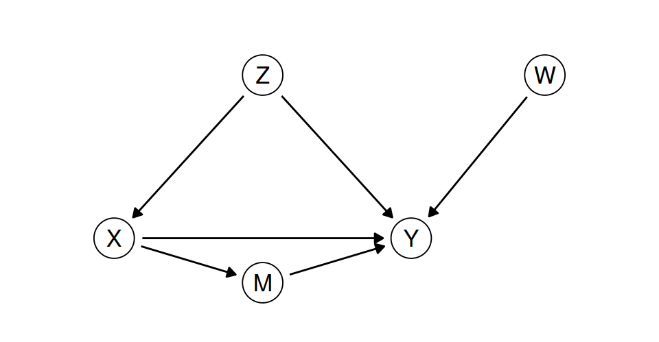

1. List the backdoor paths from $X$ to $Y$.
2. Which of these sets satisfy the backdoor criterion: the empty set, $\{Z\}$, $\{M\}$, $\{Z, M\}$, $\{W\}$, $\{Z, W\}$?
3. In a linear model, what does the coefficient on $X$ estimate if you adjust for $\{Z, M\}$?
4. If more than one of the sets in (b) satisfies the criterion, which would you use, and why?

**TipHint 1**

A backdoor path starts with an arrow into $X$. How many arrows point into $X$?

**NoteSolution**

1. One: $X \leftarrow Z \to Y$.
2. $\{Z\}$ and $\{Z, W\}$. The empty set and $\{W\}$ leave the back door open. $\{M\}$ and $\{Z, M\}$ contain a descendant of $X$.
3. The direct effect of $X$, along the arrow $X \to Y$: the part that does not go through $M$. It is not the total effect of $X$. (It is the direct effect because in this graph nothing else affects both $M$ and $Y$.)
4. $\{Z\}$ and $\{Z, W\}$ both satisfy it. Use $\{Z, W\}$: $W$ is not a confounder, so leaving it out causes no bias, but it explains some of the variation in $Y$, and the estimate that uses it is usually less variable.

### 5. The graph behind an argument

A university says: “Students who use the library more get better grades. We will extend the library’s opening hours, because using the library improves grades.”

1. Draw the causal graph the argument presupposes, and mark the action.
2. Add one variable that would make the observed difference larger than the effect, with its arrows.
3. What comparison would support the university’s claim?

**TipHint 1**

The university’s evidence compares students. Its action changes opening hours. Are those the same thing?

**NoteSolution**

1. Opening hours (the action) $\to$ library use $\to$ grades. The argument needs the arrow from library use to grades, and an arrow from opening hours to library use.
2. For example motivation, or how well a student was already doing, with arrows into library use and into grades. If it raises both, the students who use the library more would have had better grades anyway, so the observed difference is larger than the effect.
3. Grades before and after the hours were extended, against a comparable university or set of courses where they were not; or terms, or sites, chosen at random to have longer hours. The comparison of students who use the library more with those who use it less answers a question about those students.

### 6. Two registers

The decision whether to prescribe hormone therapy to prevent heart disease can be written in either register.

1. Write it in the prediction register. Say what the treatment, the outcome and a confounder are, and write the quantity a doctor needs with $do(\cdot)$.
2. Write it in the sequential-decision register, with the one-line declaration at the top. Say what the state, the action, the reward, the policy and the utility are.
3. Which letters would mean different things if you used them in both answers?

**TipHint 1**

For (a), what does the doctor choose, and what could affect both that choice and heart disease? For (b), what does the doctor know when choosing?

**NoteSolution**

1. $X = 1$ if the doctor prescribes hormone therapy, $Y = 1$ if the woman has coronary heart disease within five years, $Z$ her socioeconomic status. A doctor needs $P(Y = 1 \mid do(X := 1))$ against $P(Y = 1 \mid do(X := 0))$, not $P(Y = 1 \mid X = 1)$ against $P(Y = 1 \mid X = 0)$.
2. **Notation:** this answer uses the sequential-decision register, $S$ state, $A$ action, $R$ reward, $\pi$ policy, $U$ utility. $S$ is the patient’s state: age, time since the menopause, risk factors. $A$ is prescribe or do not. $\pi$ is the prescribing rule from state to action. $R$ is a measured reward, such as no heart attack recorded in five years. $U$ is what we care about: her health, including breast cancer, stroke and fractures as well as the heart.
3. $A$, $R$ and $U$. In the prediction register they are a sensitive attribute, a risk score and an unobserved variable.

### 7. Inverse probability weighting (harder)

Let $e(Z) = P(X = 1 \mid Z)$, strictly between 0 and 1, and suppose $Z$ satisfies the backdoor criterion.

1. Show that $E[XY/e(Z)] = \sum_z E[Y \mid X = 1, Z = z]\,P(Z = z)$ by conditioning on $Z$ first.
2. Write the matching expression for $E[Y \mid do(X := 0)]$, and check both on the table in problem 2.
3. How many students does each app user stand for, in each row, and why?
4. Why are values of $e(Z)$ near zero a problem in a sample?

**TipHint 1**

$XY$ is zero unless $X = 1$, so $E[XY \mid Z] = E[Y \mid X = 1, Z]\,P(X = 1 \mid Z)$.

**NoteSolution**

1. $E[XY/e(Z)] = E\big[E[XY \mid Z]/e(Z)\big]$, and $E[XY \mid Z] = E[Y \mid X = 1, Z]\,e(Z)$, so the $e(Z)$ cancels and $E[XY/e(Z)] = E\big[E[Y \mid X = 1, Z]\big] = \sum_z E[Y \mid X = 1, Z = z]\,P(Z = z)$, the adjustment formula.
2. $E[(1 - X)Y/(1 - e(Z))] = \sum_z E[Y \mid X = 0, Z = z]\,P(Z = z)$. In the table $e(1) = 0.8$ and $e(0) = 0.2$: $0.5 \times 0.8 \times 0.8/0.8 + 0.5 \times 0.2 \times 0.5/0.2 = 0.40 + 0.25 = 0.65$, and $0.5 \times 0.2 \times 0.7/0.2 + 0.5 \times 0.8 \times 0.3/0.8 = 0.35 + 0.15 = 0.50$, as in problem 2.
3. Only 20% of the students who did not pass last year used the app, so each user among them stands for $1/0.2 = 5$ students like them; among those who passed, 80% used it, so each stands for $1/0.8 = 1.25$. Weighted, the users have the whole school’s mix of $Z$.
4. The weights are large, and a few heavily weighted students can move the estimate a long way: the estimator’s variance is large. If $e(z) = 0$ for some $z$, nobody with that $Z$ was treated, and the data say nothing about the treated outcome there.

### 8. Hormone therapy

1. The 1996 estimate (0.39) and the 2008 estimates (1.42 over the first two years, 0.96 over the whole follow-up) come from the same cohort. Which comparison did each make?
2. Draw a graph under which the 1996 estimate is confounded.
3. Which comparison matches the decision a doctor makes, and why?

**TipHint 1**

For (a), ask who is compared with whom in each analysis.

**NoteSolution**

1. 1996: women who took estrogen with progestin against women who did not use hormones, adjusted for measured confounders. 2008: women who started against women who did not start, both followed from the same point, analyzed as the trial was.
2. Socioeconomic status $\to$ hormone use, socioeconomic status $\to$ heart disease, with or without an arrow from hormone use to heart disease.
3. The 2008 comparison. The doctor’s decision is whether to start, and that comparison follows women from the point at which they started or did not.

### Coding

Open a fresh R script. You will need the tidyverse.

#### A. Prediction and intervention

```r
n <- 10000
# program 1: X causes Y
X1 <- rnorm(n); Y1 <- 2 * X1 + rnorm(n)
# program 2: Z causes both
Z2 <- rnorm(n); X2 <- Z2 + rnorm(n); Y2 <- Z2 + rnorm(n)
# program 3: X causes Y through M
X3 <- sqrt(2) * rnorm(n); M3 <- X3 + sqrt(2) * rnorm(n); Y3 <- 0.5 * M3 + rnorm(n)
```

1. Write down the slope of $Y$ on $X$ you expect in each program. Then fit `lm` and compare.
2. For each program, intervene: set $X$ to 1 for everyone and run the statements after the one for $X$ again, then the same with $X$ set to 0. Compute the difference in the means of $Y$.
3. In program 2, fit `lm(Y2 ~ X2 + Z2)`. In program 3, fit `lm(Y3 ~ X3 + M3)`. Compare the coefficients on $X$ with your answers to 2.

**TipHint 1**

In each program, which statements after the one for $X$ use $X$, directly or through a variable computed from it? Those are the ones whose values change when you set $X$.

**NoteSolution**

```r
slopes <- c(coef(lm(Y1 ~ X1))[2], coef(lm(Y2 ~ X2))[2], coef(lm(Y3 ~ X3))[2])
do1 <- c(mean(2 * 1 + rnorm(n)),                    # X set to 1, later statements re-run
         mean(Z2 + rnorm(n)),
         mean(0.5 * (1 + sqrt(2) * rnorm(n)) + rnorm(n)))
do0 <- c(mean(2 * 0 + rnorm(n)),                    # X set to 0
         mean(Z2 + rnorm(n)),
         mean(0.5 * (0 + sqrt(2) * rnorm(n)) + rnorm(n)))
round(rbind(slope = slopes, effect = do1 - do0), 2)
```

```
         X1   X2   X3
slope  2.01 0.51 0.50
effect 2.05 0.00 0.47
```

```r
round(coef(lm(Y2 ~ X2 + Z2))[2], 2)    # program 2, adjusting for Z
```

```
X2
 0
```

```r
round(coef(lm(Y3 ~ X3 + M3))[2], 2)    # program 3, adjusting for M
```

```
  X3
0.01
```

The slopes are about 2, 0.5 and 0.5. The effects are about 2, 0 and 0.5. In programs 2 and 3, $X$ and $Y$ have the same joint distribution (jointly normal, with means 0, variances 2 and 2 and covariance 1), so $X$ predicts $Y$ equally well in both, and intervening on $X$ changes $Y$ only in program 3. Adjusting for $Z$ in program 2 gives a coefficient near 0, the effect. Adjusting for $M$ in program 3 also gives a coefficient near 0. That is the direct effect, zero here because $X$ reaches $Y$ only through the mediator $M$; the total effect is 0.5.

#### B. Adjustment and weighting on data

```r
cells <- data.frame(Z = c(1, 1, 0, 0), X = c(1, 0, 1, 0),
                    n = c(400, 100, 100, 400), passed = c(320, 70, 50, 120))
students <- bind_rows(
  cells |> mutate(Y = 1, count = passed),
  cells |> mutate(Y = 0, count = n - passed)
) |>
  select(Z, X, Y, count) |>
  tidyr::uncount(count)
nrow(students)
```

```
[1] 1000
```

1. Compute the pass rates of users and non-users from `students`, and their difference.
2. Compute the adjusted difference: the difference in pass rates within each value of $Z$, averaged with weights $P(Z = z)$.
3. Compute $e(Z)$, the share of users within each value of $Z$, attach it to each student, and compute `mean(X * Y / e)` and `mean((1 - X) * Y / (1 - e))`.
4. A randomized version: give each of 1,000 students the app with probability 0.5, whatever their $Z$, and draw whether they pass from the table’s rates. Compute the difference in pass rates. Repeat 200 times. What is the average difference, and how much does it vary?

**TipHint 1**

For 3: `students |> group_by(Z) |> mutate(e = mean(X)) |> ungroup()`.

**NoteSolution**

```r
students |> group_by(X) |> summarize(rate = mean(Y))
```

```
# A tibble: 2 x 2
      X  rate
  <dbl> <dbl>
1     0  0.38
2     1  0.74
```

```r
rows <- students |>
  group_by(Z) |>
  summarize(diff = mean(Y[X == 1]) - mean(Y[X == 0]),
            share = n() / nrow(students))
sum(rows$diff * rows$share)
```

```
[1] 0.15
```

```r
students |> group_by(Z) |> mutate(e = mean(X)) |> ungroup() |>
  summarize(do1 = mean(X * Y / e), do0 = mean((1 - X) * Y / (1 - e)))
```

```
# A tibble: 1 x 2
    do1   do0
  <dbl> <dbl>
1  0.65   0.5
```

```r
rate <- function(z, x) {
  ifelse(z == 1, ifelse(x == 1, 0.8, 0.7), ifelse(x == 1, 0.5, 0.3))
}
one_trial <- function() {
  Z <- rep(c(1, 0), each = 500)
  X <- rbinom(1000, 1, 0.5)
  Y <- rbinom(1000, 1, rate(Z, X))
  mean(Y[X == 1]) - mean(Y[X == 0])
}
trials <- replicate(200, one_trial())
c(mean = mean(trials), sd = sd(trials))
```

```
      mean         sd
0.15259676 0.02994598
```

1. 0.74 and 0.38, a difference of 0.36.
2. 0.15.
3. 0.65 and 0.50, the adjustment formula’s numbers.
4. The average is close to 0.15, and the differences vary from trial to trial with a standard deviation of about 0.03. Randomization removes the bias without any model of $Z$, and the price is that a single trial can miss by a few points.